# Project Case Scenario: Boston Real Estate

## Overview

- Programming language: Python
- Tools: NumPy, pandas, Matplotlib, Seaborn, and Plotly in Jupyter Notebook
- Objective: as a data scientist at a real estate agency in Boston, MA, use the following dataset to provide insight into the following questions for Boston real estate.
  1. Visualize the median value of owner-occupied homes using two different methods of plotting.
  2. Is there a significant difference in the median value of houses bounded and not bounded by the Charles River?
  3. Is there a difference in the median values of houses for each proportion of owner-occupied units built before 1940?
  4. Is there a relationship between nitric oxide concentrations and the proportion of non-retail business acres per town?
  5. What is the impact of an additional weighted distance to the five Boston employment centres on the median value of owner-occupied homes?
- Dataset: housing information and prices derived from the U.S. Census Service.
- Dataset variables:
  - *CRIM*: per capita crime rate by town
  - *ZN*: proportion of residential land zoned for lots over 25,000 square feet
  - *INDUS*: proportion of non-retail business acres per town
  - *CHAS*: whether the tract bounds the Charles River (1 if tract bounds river, 0 if the tract does not)
  - *NOX*: nitric oxides concentration (parts per 10 million)
  - *RM*: average number of rooms per dwelling
  - *AGE*: proportion of owner-occupied units built prior to 1940
  - *DIS*: weighted distances to five Boston employment centers
  - *RAD*: index of accessibility to radial highways
  - *TAX*: full-value property-tax rate per $10,000
  - *PTRATIO*: pupil-teacher ratio by town
  - *LSTAT*: percentage lower status of the population
  - *MEDV*: Median value of owner-occupied homes in units of $1,000
- This project was initially completed as part of Coursera's IBM "Statistics for Data Science with Python" course. I also independently refined and extended it by adding additional code, analyses, and visualizations.
- Set Up
- Data Exploration
- Objective #1
  - Visualize the median value of owner-occupied homes using two different methods of plotting.
- Objective #2
  - Is there a significant difference in the median value of houses bounded and not bounded by the Charles River?
- Objective #3
  - Is there a difference in the median values of houses for each proportion of owner-occupied units built before 1940?
- Objective #4
  - Is there a relationship between nitric oxide concentrations and the proportion of non-retail business acres per town?
- Objective #5
  - What is the impact of an additional weighted distance to the five Boston employment centres on the median value of owner-occupied homes?

### Set Up

#### Import Libraries

Load the necessary libraries and surpress warnings.

```python
#pip install -U seaborn
```

```python
# Surpress warnings:
def warn(*args, **kwargs):
    pass
import warnings
warnings.warn = warn
```

```python
import numpy as np
import pandas as pd
import seaborn as sns
import scipy.stats
import statsmodels.api as sm
from statsmodels.stats.multicomp import pairwise_tukeyhsd
import plotly.express as px
import plotly.graph_objects as go
import matplotlib as mpl
import matplotlib.pyplot as plt
%matplotlib inline
```

#### Import Data

Load the real estate dataset and drop the first column.

```python
# load data
boston_url = 'https://cf-courses-data.s3.us.cloud-object-storage.appdomain.cloud/IBMDeveloperSkillsNetwork-ST0151EN-SkillsNetwork/labs/boston_housing.csv'
boston_df = pd.read_csv(boston_url)
boston_df.drop('Unnamed: 0', axis=1, inplace=True) #remove unused variable
```

Add a new variable to represent the full value of owner-occupied homes.

```python
# calculate variable for full value
boston_df["MEDV_units"] = boston_df["MEDV"]*1000
```

### Data Exploration

Find the size, variable types, and descriptive statistics of the dataset.

```python
# find the size of dataset
print("There are currently", boston_df.shape[0], "rows and", boston_df.shape[1], "variables in this dataset.")
```

```
There are currently 506 rows and 14 variables in this dataset.
```

```python
# load the first five rows of the dataset
boston_df.head()
```

|  | CRIM | ZN | INDUS | CHAS | NOX | RM | AGE | DIS | RAD | TAX | PTRATIO | LSTAT | MEDV | MEDV_units |
| --- | --- | --- | --- | --- | --- | --- | --- | --- | --- | --- | --- | --- | --- | --- |
| 0 | 0.00632 | 18.0 | 2.31 | 0.0 | 0.538 | 6.575 | 65.2 | 4.0900 | 1.0 | 296.0 | 15.3 | 4.98 | 24.0 | 24000.0 |
| 1 | 0.02731 | 0.0 | 7.07 | 0.0 | 0.469 | 6.421 | 78.9 | 4.9671 | 2.0 | 242.0 | 17.8 | 9.14 | 21.6 | 21600.0 |
| 2 | 0.02729 | 0.0 | 7.07 | 0.0 | 0.469 | 7.185 | 61.1 | 4.9671 | 2.0 | 242.0 | 17.8 | 4.03 | 34.7 | 34700.0 |
| 3 | 0.03237 | 0.0 | 2.18 | 0.0 | 0.458 | 6.998 | 45.8 | 6.0622 | 3.0 | 222.0 | 18.7 | 2.94 | 33.4 | 33400.0 |
| 4 | 0.06905 | 0.0 | 2.18 | 0.0 | 0.458 | 7.147 | 54.2 | 6.0622 | 3.0 | 222.0 | 18.7 | 5.33 | 36.2 | 36200.0 |

```python
# find the variable types
boston_df.info()
```

```
<class 'pandas.core.frame.DataFrame'>
RangeIndex: 506 entries, 0 to 505
Data columns (total 14 columns):
 #   Column      Non-Null Count  Dtype
---  ------      --------------  -----
 0   CRIM        506 non-null    float64
 1   ZN          506 non-null    float64
 2   INDUS       506 non-null    float64
 3   CHAS        506 non-null    float64
 4   NOX         506 non-null    float64
 5   RM          506 non-null    float64
 6   AGE         506 non-null    float64
 7   DIS         506 non-null    float64
 8   RAD         506 non-null    float64
 9   TAX         506 non-null    float64
 10  PTRATIO     506 non-null    float64
 11  LSTAT       506 non-null    float64
 12  MEDV        506 non-null    float64
 13  MEDV_units  506 non-null    float64
dtypes: float64(14)
memory usage: 55.5 KB
```

```python
# descriptive statistics for all variables
boston_df.describe()
```

|  | CRIM | ZN | INDUS | CHAS | NOX | RM | AGE | DIS | RAD | TAX | PTRATIO | LSTAT | MEDV | MEDV_units |
| --- | --- | --- | --- | --- | --- | --- | --- | --- | --- | --- | --- | --- | --- | --- |
| count | 506.000000 | 506.000000 | 506.000000 | 506.000000 | 506.000000 | 506.000000 | 506.000000 | 506.000000 | 506.000000 | 506.000000 | 506.000000 | 506.000000 | 506.000000 | 506.000000 |
| mean | 3.613524 | 11.363636 | 11.136779 | 0.069170 | 0.554695 | 6.284634 | 68.574901 | 3.795043 | 9.549407 | 408.237154 | 18.455534 | 12.653063 | 22.532806 | 22532.806324 |
| std | 8.601545 | 23.322453 | 6.860353 | 0.253994 | 0.115878 | 0.702617 | 28.148861 | 2.105710 | 8.707259 | 168.537116 | 2.164946 | 7.141062 | 9.197104 | 9197.104087 |
| min | 0.006320 | 0.000000 | 0.460000 | 0.000000 | 0.385000 | 3.561000 | 2.900000 | 1.129600 | 1.000000 | 187.000000 | 12.600000 | 1.730000 | 5.000000 | 5000.000000 |
| 25% | 0.082045 | 0.000000 | 5.190000 | 0.000000 | 0.449000 | 5.885500 | 45.025000 | 2.100175 | 4.000000 | 279.000000 | 17.400000 | 6.950000 | 17.025000 | 17025.000000 |
| 50% | 0.256510 | 0.000000 | 9.690000 | 0.000000 | 0.538000 | 6.208500 | 77.500000 | 3.207450 | 5.000000 | 330.000000 | 19.050000 | 11.360000 | 21.200000 | 21200.000000 |
| 75% | 3.677083 | 12.500000 | 18.100000 | 0.000000 | 0.624000 | 6.623500 | 94.075000 | 5.188425 | 24.000000 | 666.000000 | 20.200000 | 16.955000 | 25.000000 | 25000.000000 |
| max | 88.976200 | 100.000000 | 27.740000 | 1.000000 | 0.871000 | 8.780000 | 100.000000 | 12.126500 | 24.000000 | 711.000000 | 22.000000 | 37.970000 | 50.000000 | 50000.000000 |

### Objective #1: visualize the median value of owner-occupied homes using two different libraries for plotting.

Boxplots are created to assess the price distribution of owner-occupied homes. Boxplots will be plotted using two different Python libraries, Seaborn and Plotly.

#### Method #1: a non-interactive visualization with Seaborn

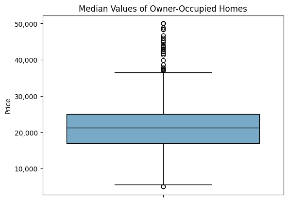

```python
# graphing a boxplot with Seaborn
sns.reset_orig()
ax = sns.boxplot(data=boston_df,
                 y="MEDV_units",
                 linecolor="black",
                 palette="Blues",
                 )
ax.set(ylabel = "Price", title ='Median Values of Owner-Occupied Homes')
ax.get_yaxis().set_major_formatter(mpl.ticker.StrMethodFormatter('{x:,.0f}'))
plt.show()
```

#### Method #2: an interactive visualization with Plotly

```python
# graphing a boxplot with Plotly
fig = px.box(boston_df,
             y="MEDV_units",
             width = 500,
             height = 600,
             title ='Median Values of Owner-Occupied Homes',
             labels={"MEDV_units": "Price"},
             template="simple_white"
            )
fig.update_layout(title_x=0.5)
fig.update_layout(margin=dict(l=30, r=30, t=50, b=20))
fig.show()
```

[interactive chart not shown]

```python
# funcs = [np.mean, np.std, ]
# func_name = ["average", "standard deviation"]

# for i, func in enumerate(funcs):
#     print("The ",func_name[i]," is ${:,.2f}".format(boston_df['MEDV_units'].aggregate(func)), ".", sep="")
#https://stackoverflow.com/questions/71495591/how-to-loop-over-functions-like-mean-max-std-by-putting-them-in-a-list
```

From the boxplots, it seems like there is a large spread of house values, with the median value of houses appearing to be slightly over $20,000. Descriptive statistics can be calculated to provide additional information on the distribution of house values.

```python
# print descriptive statistics
print("\nBasic descriptive statistics can seen here:")
# print("The average median value is: $", "%.2f" % round(boston_df['MEDV_units'].mean(),2) )
# print("The standard deviation is: $", "%.2f" % round(boston_df['MEDV_units'].std(),2) )
# print("The median of the median value is: $", "%.2f" % round(boston_df['MEDV_units'].median(),2) )
# print("The lowest median value is: $", "%.2f" % round(boston_df['MEDV_units'].min(),2))
# print("The highest median value is: $", "%.2f" % round(boston_df['MEDV_units'].max(),2))
funcs = {'average': np.mean,
         'standard deviation': np.std,
         'median': np.median,
         'lowest': np.min,
         'highest': np.max}

for key, value in funcs.items():
    print("\tThe ", key," value is ${:,.2f}".format(boston_df['MEDV_units'].aggregate(value)), ".", sep="")

#https://stackoverflow.com/questions/74567578/how-do-i-loop-through-a-dictionary-and-apply-a-function-using-key-value-pairs

# print descriptive statistics in dataframe
print("\nAdditional descriptive statistics:\n")
MEDV_table = pd.DataFrame(boston_df["MEDV_units"].describe().round(2)).style.format('{:,.2f}')
MEDV_table.columns = ["Median Value of Homes"]
MEDV_table
```

```
Basic descriptive statistics can seen here:
	The average value is $22,532.81.
	The standard deviation value is $9,197.10.
	The median value is $21,200.00.
	The lowest value is $5,000.00.
	The highest value is $50,000.00.

Additional descriptive statistics:
```

|  | MEDV_units |
| --- | --- |
| count | 506.00 |
| mean | 22,532.81 |
| std | 9,197.10 |
| min | 5,000.00 |
| 25% | 17,025.00 |
| 50% | 21,200.00 |
| 75% | 25,000.00 |
| max | 50,000.00 |

From the boxplots and descriptive statistics, the range of house values in this dataset span from `$5,000.00` to `$50,000.00`, with the median value at `$21,200` and the mean value at `$22,532.81`.

### Objective #2: is there a significant difference in the median value of houses bounded by the Charles River?

#### Visualize real estate by the Charles River

A bar chart is first created to compare the number of houses bounding and not bounding the Charles River. Houses that are not surrounding the river are represented in orange while houses located by the river are shown in blue.

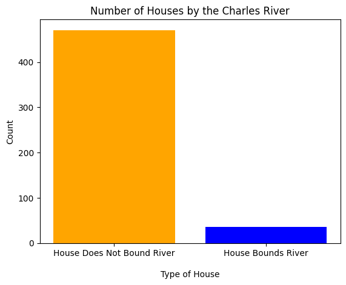

```
Number of houses that do not bound the Charles River: 471
Number of houses bound the Charles River: 35
```

```python
# create a variable to display the binary values as strings
boston_df.loc[(boston_df['CHAS'] == 0), 'CHAS_STRING'] = 'House Does Not Bound River'
boston_df.loc[(boston_df['CHAS'] == 1), 'CHAS_STRING'] = 'House Bounds River'

# graphing a bar chart with Matplotlib
plt.bar(boston_df.CHAS_STRING.unique(),
        boston_df.CHAS_STRING.value_counts(),
        color=['orange','blue'])
plt.xlabel('\nType of House')
plt.ylabel('Count')
plt.title('Number of Houses by the Charles River')
plt.show()

# print descriptive statistics
CHAS_counts = boston_df.CHAS_STRING.value_counts()
print("\nNumber of houses that do not bound the Charles River:", CHAS_counts[0])
print("Number of houses bound the Charles River:", CHAS_counts[1],"\n")
```

There are more houses that do not bound the Charles River than houses that bound it.

A boxplot can be used to visualize any potential price differences between these different types of houses. As with the above bar chart, houses that are not located by the river are represented in orange while houses next to the river are shown in blue.

```python
# graphing a boxplot with Plotly
fig = px.box(boston_df,
             x="CHAS_STRING",
             y="MEDV_units",
             width = 700,
             height = 600,
             title ='Price Differences Based on Bounding the Charles River',
             labels={
                 "MEDV_units": "Price",
                 "CHAS_STRING":"Type of House"},
             color="CHAS_STRING",
             color_discrete_sequence=["orange", "blue"],
             template="simple_white")
fig.update_layout(title_x=0.5)
fig.update_layout(margin=dict(l=30, r=30, t=50, b=20))
fig.show()

# descriptive statistics
print("\nDescriptive statistics for each group's housing values are as follows:\n")
CHAS_STRING_table = boston_df.groupby("CHAS_STRING").aggregate("MEDV_units").describe().round(2).style.format('{:,.2f}')
CHAS_STRING_table.index.name = "Type of House"
CHAS_STRING_table
```

[interactive chart not shown]

```
Descriptive statistics for each group's housing values are as follows:
```

| Type of House | count | mean | std | min | 25% | 50% | 75% | max |
| --- | --- | --- | --- | --- | --- | --- | --- | --- |
| House Bounds River | 35.00 | 28,440.00 | 11,816.64 | 13,400.00 | 21,100.00 | 23,300.00 | 33,150.00 | 50,000.00 |
| House Does Not Bound River | 471.00 | 22,093.84 | 8,831.36 | 5,000.00 | 16,600.00 | 20,900.00 | 24,800.00 | 50,000.00 |

From the boxplot, the mean value of houses that do not bound the Charles River seem to be relatively lower than the mean value of houses that bound the river. The descriptive statistics also support this.

#### Statistical analysis

A t-test for independent samples is conducted to determine whether there is a significant difference in the median value of houses depending on their location to the Charles River.

- Null hypothesis: there is no difference in the median value of houses bounded by the Charles River.
- Alternative hypothesis: there is a difference in the median value of houses bounded by the Charles River.

Levene's test is first conducted to assess whether the variances between groups are equal.

```python
# Levene's test to evaluate whether variances between groups are equal
Levene_test = scipy.stats.levene(boston_df[boston_df['CHAS'] == 0]['MEDV_units'],
                   boston_df[boston_df['CHAS'] == 1]['MEDV_units'], center='mean')

print("\nLevene's test results:")
print("\t", Levene_test, sep="")

print("\nLevene's test results in a p-value of ", Levene_test[1].round(3),", which suggests the variances between groups are not equal. As such, the t-test for independent samples will be conducted with unequal variances.\n", sep="")
```

```
Levene's test results:
	LeveneResult(statistic=8.751904896045989, pvalue=0.003238119367639829)

Levene's test results in a p-value of 0.003, which suggests the variances between groups are not equal. As such, the t-test for independent samples will be conducted with unequal variances.
```

```python
# t-test
ttest_var = scipy.stats.ttest_ind(boston_df[boston_df['CHAS'] == 0]['MEDV_units'],
                   boston_df[boston_df['CHAS'] == 1]['MEDV_units'], equal_var = False)
print("\nResults of a t-test with unequal variances:")
print("\t", ttest_var, "\n", sep="")

if ttest_var[1].round(3) < 0.05:
    print("The t-test results in a p-value of ", ttest_var[1].round(3), ". Since the p-value is less than α = 0.05, we reject the null hypothesis.", sep="")
else:
    print("The t-test results in a p-value of ", ttest_var[1].round(3), ". Since the p-value is greater than α = 0.05, we fail to reject the null hypothesis.", sep="")
```

```
Results of a t-test with unequal variances:
	TtestResult(statistic=-3.11329131279484, pvalue=0.0035671700981374896, df=36.87640879761199)

The t-test results in a p-value of 0.004. Since the p-value is less than α = 0.05, we reject the null hypothesis.
```

#### Conclusion

This test suggests there is a significant difference in the median value of houses bounded and not bounded by the Charles River.

### Objective #3: is there a significant difference in median values of houses for each proportion of owner-occupied units built before 1940?

The following graph and analyses compare the median price of owner-occupied homes built before 1940 by their age, which is discretized into three groups (houses 35 years and younger, houses between 35 and 70 years, and houses that are 70 years and older).

The age of the units built before 1940 will first be partitioned into three groups for analysis.

```python
# discretize age groups
boston_df.loc[(boston_df['AGE'] <= 35), 'age_group'] = '35 Years and Younger'
boston_df.loc[(boston_df['AGE'] > 35)&(boston_df['AGE'] < 70), 'age_group'] = 'Between 35 and 70 Years'
boston_df.loc[(boston_df['AGE'] >= 70), 'age_group'] = '70 Years and Older'
```

#### Visualize the median values of homes built before 1940 by their age

A boxplot is used to compare the price distribution of owner-occupied homes by their age.

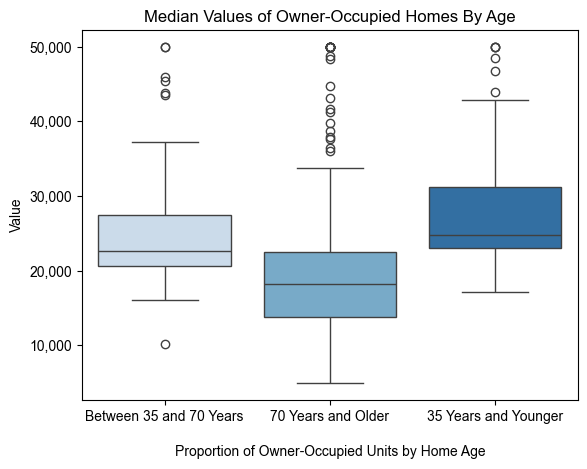

```
Descriptive statistics of each group's housing price are as follows:
```

| age_group | count | mean | std | min | 25% | 50% | 75% | max |
| --- | --- | --- | --- | --- | --- | --- | --- | --- |
| 35 Years and Younger | 91.0 | 27775.82 | 7638.20 | 17100.0 | 23050.0 | 24800.0 | 31150.0 | 50000.0 |
| 70 Years and Older | 287.0 | 19793.38 | 9515.38 | 5000.0 | 13800.0 | 18200.0 | 22550.0 | 50000.0 |
| Between 35 and 70 Years | 128.0 | 24947.66 | 6969.37 | 10200.0 | 20675.0 | 22600.0 | 27425.0 | 50000.0 |

```python
# boxplot
sns.reset_orig()
ax = sns.boxplot(data=boston_df, x="age_group", y="MEDV_units", palette="Blues")
ax.set(xlabel="\nProportion of Owner-Occupied Units by Home Age", ylabel = "Value", title ='Median Values of Owner-Occupied Homes By Age')
sns.set(rc={'figure.figsize':(13,10)})
ax.get_yaxis().set_major_formatter(mpl.ticker.StrMethodFormatter('{x:,.0f}'))
plt.show()

print("\nDescriptive statistics of each group's housing price are as follows:\n")
boston_df.groupby("age_group").aggregate("MEDV_units").describe().round(2)
```

From the boxplot, it seems houses that are 70 years and older have relatively lower values, while houses that are 35 years and younger have relatively higher values. The descriptive statistics of each age group supports this perceived price difference.

#### Statistical analysis

An ANOVA is conducted to determine whether there is a significant difference in the median price of houses for each proportion of owner-occupied units built before 1940.

- Null hypothesis: there is no difference in the median value of houses for each proportion of owner-occupied units built prior to 1940.
- Alternative hypothesis: there is a difference in the median value of houses for each proportion of owner-occupied units built prior to 1940.

```python
# ANOVA
ANOVA_group1 = boston_df[boston_df['age_group'] == '35 Years and Younger']['MEDV_units']
ANOVA_group2 = boston_df[boston_df['age_group'] == 'Between 35 and 70 Years']['MEDV_units']
ANOVA_group3 = boston_df[boston_df['age_group'] == '70 Years and Older']['MEDV_units']

ANOVA_var = scipy.stats.f_oneway(ANOVA_group1, ANOVA_group2, ANOVA_group3)

print("\nANOVA results:")
print("\t",ANOVA_var,sep="")

print("\nAn ANOVA results in a p-value of {:0.3e}".format(ANOVA_var[1]), ". Since this p-value is less than α = 0.05, we reject the null hypothesis.\n", sep="")
```

```
ANOVA results:
	F_onewayResult(statistic=36.40764999196602, pvalue=1.7105011022701769e-15)

An ANOVA results in a p-value of 1.711e-15. Since this p-value is less than α = 0.05, we reject the null hypothesis.
```

Since the ANOVA above is significant, a post hoc analysis using Tukey's HSD test to correct for multiple comparisons is then conducted to evaluate whether differences between group means are significant.

```python
print(pairwise_tukeyhsd(boston_df['MEDV_units'], boston_df['age_group']))
```

```
                    Multiple Comparison of Means - Tukey HSD, FWER=0.05
============================================================================================
       group1                 group2          meandiff  p-adj     lower      upper    reject
--------------------------------------------------------------------------------------------
35 Years and Younger      70 Years and Older -7982.4444    0.0 -10418.1857 -5546.7031   True
35 Years and Younger Between 35 and 70 Years -2828.1679 0.0447  -5604.3202   -52.0157   True
  70 Years and Older Between 35 and 70 Years  5154.2765    0.0   3002.3619   7306.191   True
--------------------------------------------------------------------------------------------
```

The results from the posthoc Tukey's HSD test suggests that the price of all three groups is significantly different from one another. The average median price of houses 35 years and younger is the highest of the three groups, followed by houses between 35 and 70 years. Hhouses that are 70 years and older had the lowest average median price of the three groups.

#### Conclusion

An ANOVA test suggests there is a significant difference in the median value of houses for each proportion of owner-occupied homes built prior to 1940. That is, houses differ in their median value based on their age. Specifically, the average median price of houses 35 years and younger is the highest of the three groups while the average median price of houses 70 years and older is the lowest of the three groups.

### Objective #4: is there a relationship between nitric oxide concentrations and the proportion of non-retail business acres per town?

Assessing the dataset shows that there are several duplicated values for the "INDUS" and "NOX" variables. This means that the same values for the proportion of non-retail business acres per town and nitric oxide concentrations were reported several times, which may prevent accurate results if the dataset is used without proper formatting. To resolve this, rows with duplicate values in the variable are discarded so that only rows with unique values remain.

```python
# retain only unique values of "INDUS"
boston_df_no_INDUS_duplicates = boston_df.drop_duplicates(subset=["INDUS"])
```

```python
# find size of dataset
print('The new dataset includes', boston_df_no_INDUS_duplicates.shape[0], 'rows and', boston_df_no_INDUS_duplicates.shape[1], 'columns.')
```

```
The new dataset includes 76 rows and 16 columns.
```

#### Visualize the relationship between nitric oxide concentrations and the proportion of non-retail business acres per town.

A scatterplot is created to assess the relationship between the two variables.

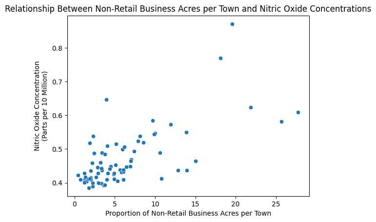

```python
sns.reset_orig()
ax = sns.scatterplot(x="INDUS", y="NOX", data=boston_df_no_INDUS_duplicates)
ax.set(xlabel="Proportion of Non-Retail Business Acres per Town",
       ylabel = "Nitric Oxide Concentration\n(Parts per 10 Million)",
       title ='Relationship Between Non-Retail Business Acres per Town and Nitric Oxide Concentrations')
plt.show()
```

There seems to be a positive, linear relationship between the proportion of non-retail business acres per town and the nitric oxide concentrations. Greater proportions of non-retail businesses seems to be related to greater nitric oxide concentrations.

#### Statistical analysis

A Pearson Correlation is conducted to determine whether there is a significant relationship between nitric oxide concentrations and the proportion of non-retail business acres per town.

- Null hypothesis: there is no relationship between nitric oxide concentrations and the proportion of non-retail business acres per town.
- Alternative hypothesis: there is a relationship between nitric oxide concentrations and the proportion of non-retail business acres per town.

```python
# Pearson Correlation
pearsonr_var = scipy.stats.pearsonr(boston_df_no_INDUS_duplicates['INDUS'], boston_df_no_INDUS_duplicates['NOX'])

print("\nPearson Correlation results:")
print("\t",pearsonr_var,sep="")

print("\nA Pearson Correlation results in a p-value of {:0.3e}".format(pearsonr_var[1]), ".", sep="")
print("Since this p-value is less than α = 0.05, we reject the null hypothesis.\n")
```

```
Pearson Correlation results:
	PearsonRResult(statistic=0.6809525800688366, pvalue=1.3018316252583866e-11)

A Pearson Correlation results in a p-value of 1.302e-11.
Since this p-value is less than α = 0.05, we reject the null hypothesis.
```

#### Conclusion

This test suggests there is a significant relationship between nitric oxide concentrations and the proportion of non-retail business acres per town. Nitric oxide concentrations and the proportion of non-retail business acres is positively correlated, with increases in one variable associated with increases in the other.

### Objective #5: what is the impact of an additional weighted distance to the five Boston employment centers on the median value of owner-occupied homes?

#### Statistical analysis

A linear regression is conducted to determine whether there is a significant relationship between weighted distance to the Boston employment centers and median price of owner-occupied homes.

- Null hypothesis: there is no relationship between the weighted distance to the five Boston employment centers and the median value of owner-occupied homes.
- Alternative hypothesis: there is a relationship between the weighted distance to the five Boston employment centers and the median value of owner-occupied homes.

```python
X = boston_df["DIS"]
y = boston_df["MEDV_units"]
X = sm.add_constant(X)

model = sm.OLS(y, X).fit()
predictions = model.predict(X)

print("\nRegression results:")
print(model.summary())

# print("\nA regression results in a p-value of {:0.3e}".format(model.pvalues[1]), ".", sep="")

if model.pvalues[1].round(3) < 0.05:
    print("\nThe regression results in a p-value of {:0.3e}".format(model.pvalues[1]), "for the independent variable. Since the p-value is less than α = 0.05, we reject the null hypothesis.", sep="")
else:
    print("\nThe regression results in a p-value of {:0.3e}".format(model.pvalues[1]), "for the independent variable. Since the p-value is greater than α = 0.05, we fail to reject the null hypothesis.", sep="")

print("\nFor every additional 1 unit of weighted distance to the five Boston employment centers, the median house price increases on average by ${:0.2f}".format(model.params[1]), ".\n",sep="")
```

```
Regression results:
                            OLS Regression Results
==============================================================================
Dep. Variable:             MEDV_units   R-squared:                       0.062
Model:                            OLS   Adj. R-squared:                  0.061
Method:                 Least Squares   F-statistic:                     33.58
Date:                Mon, 15 Apr 2024   Prob (F-statistic):           1.21e-08
Time:                        20:13:48   Log-Likelihood:                -5319.2
No. Observations:                 506   AIC:                         1.064e+04
Df Residuals:                     504   BIC:                         1.065e+04
Df Model:                           1
Covariance Type:            nonrobust
==============================================================================
                 coef    std err          t      P>|t|      [0.025      0.975]
------------------------------------------------------------------------------
const       1.839e+04    817.389     22.499      0.000    1.68e+04       2e+04
DIS         1091.6130    188.378      5.795      0.000     721.509    1461.717
==============================================================================
Omnibus:                      139.779   Durbin-Watson:                   0.570
Prob(Omnibus):                  0.000   Jarque-Bera (JB):              305.104
Skew:                           1.466   Prob(JB):                     5.59e-67
Kurtosis:                       5.424   Cond. No.                         9.32
==============================================================================

Notes:
[1] Standard Errors assume that the covariance matrix of the errors is correctly specified.

The regression results in a p-value of 1.207e-08for the independent variable. Since the p-value is less than α = 0.05, we reject the null hypothesis.

For every additional 1 unit of weighted distance to the five Boston employment centers, the median house price increases on average by $1091.61.
```

#### Conclusion

This test suggests there is a significant relationship between the weighted distance to the five Boston employment centers and the median value of owner-occupied homes. Greater distances to the employment centers was associated with greater increases in housing prices.